# Prospers Loan Dataset Exploration

## by Mostafa ElZayat

## Preliminary Wrangling

|  | ListingKey | ListingNumber | ListingCreationDate | CreditGrade | Term | LoanStatus | ClosedDate | BorrowerAPR | BorrowerRate | LenderYield | ... | LP_ServiceFees | LP_CollectionFees | LP_GrossPrincipalLoss | LP_NetPrincipalLoss | LP_NonPrincipalRecoverypayments | PercentFunded | Recommendations | InvestmentFromFriendsCount | InvestmentFromFriendsAmount | Investors |
| --- | --- | --- | --- | --- | --- | --- | --- | --- | --- | --- | --- | --- | --- | --- | --- | --- | --- | --- | --- | --- | --- |
| 0 | 1021339766868145413AB3B | 193129 | 2007-08-26 19:09:29.263000000 | C | 36 | Completed | 2009-08-14 00:00:00 | 0.16516 | 0.1580 | 0.1380 | ... | -133.18 | 0.0 | 0.0 | 0.0 | 0.0 | 1.0 | 0 | 0 | 0.0 | 258 |
| 1 | 10273602499503308B223C1 | 1209647 | 2014-02-27 08:28:07.900000000 | NaN | 36 | Current | NaN | 0.12016 | 0.0920 | 0.0820 | ... | 0.00 | 0.0 | 0.0 | 0.0 | 0.0 | 1.0 | 0 | 0 | 0.0 | 1 |
| 2 | 0EE9337825851032864889A | 81716 | 2007-01-05 15:00:47.090000000 | HR | 36 | Completed | 2009-12-17 00:00:00 | 0.28269 | 0.2750 | 0.2400 | ... | -24.20 | 0.0 | 0.0 | 0.0 | 0.0 | 1.0 | 0 | 0 | 0.0 | 41 |
| 3 | 0EF5356002482715299901A | 658116 | 2012-10-22 11:02:35.010000000 | NaN | 36 | Current | NaN | 0.12528 | 0.0974 | 0.0874 | ... | -108.01 | 0.0 | 0.0 | 0.0 | 0.0 | 1.0 | 0 | 0 | 0.0 | 158 |
| 4 | 0F023589499656230C5E3E2 | 909464 | 2013-09-14 18:38:39.097000000 | NaN | 36 | Current | NaN | 0.24614 | 0.2085 | 0.1985 | ... | -60.27 | 0.0 | 0.0 | 0.0 | 0.0 | 1.0 | 0 | 0 | 0.0 | 20 |

5 rows × 81 columns

### What is the structure of your dataset?

**Original Dataset**

> This dataset consists of 113937 rows representing differencet customers application of Loans with 81 feature columns as follows:
> > - 50 float
> > - 17 categorical
> > - 11 int
> > - 3 boolean

**Investigation Dataset**

> This dataset is subset of original dataset with 15 columns of interest to be explored there data types are as follows
> > - 5 float
> > - 5 categorical
> > - 5 int

**Clean Dataset**

> This dataset is a cleaner versoin of investigation dataframe 'df_loans' with no null values and no duplicates, for the sake of this exercise null values and duplicates have been dropped while maintating **96%** of the data

### What features in the dataset do you think will help support your investigation into your feature(s) of interest?

**Investigation Dataset**

> Below is a list of colums considred in this nalysis as features of interest
> > - EmploymentStatus
> > - LoanStatus
> > - **BorrowerAPR**
> > - **BorrowerRate**
> > - ProsperScore
> > - Occupation
> > - IncomeRange
> > - StatedMonthlyIncome
> > - **LoanOriginalAmount**
> > - LoanOriginationDate
> > - MonthlyLoanPayment
> > - Recommendations
> > - InvestmentFromFriendsCount
> > - InvestmentFromFriendsAmount
> > - Investors

## EDA and data cleaning

- Filling Na
- Duplicates
- Data types conversion
- Data quality checks

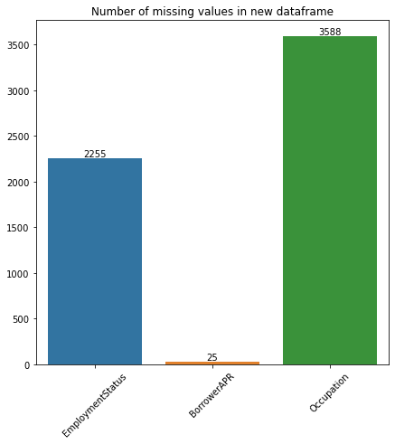

```
New dataframe with no nulls is 96.85% % of orignal dataframe
```

```
817
New dataframe with no nulls and duplicates is 96.13% % of orignal dataframe
```

> **df_clean** is now a clean dataset with no null values, duplicates so we are ready to go to next step and start data exploration

|  | count | mean | std | min | 25% | 50% | 75% | max |
| --- | --- | --- | --- | --- | --- | --- | --- | --- |
| BorrowerAPR | 109532.0 | 0.219515 | 0.080744 | 0.00653 | 0.15629 | 0.210250 | 0.285440 | 4.239500e-01 |
| BorrowerRate | 109532.0 | 0.193234 | 0.075114 | 0.00000 | 0.13420 | 0.184000 | 0.251100 | 3.600000e-01 |
| StatedMonthlyIncome | 109532.0 | 5636.324330 | 7584.093974 | 0.00000 | 3250.00000 | 4666.666667 | 6833.333333 | 1.750003e+06 |
| LoanOriginalAmount | 109532.0 | 8397.743381 | 6259.145526 | 1000.00000 | 4000.00000 | 6500.000000 | 12000.000000 | 3.500000e+04 |
| MonthlyLoanPayment | 109532.0 | 274.421556 | 193.022458 | 0.00000 | 133.80000 | 220.955000 | 372.710000 | 2.251510e+03 |
| Recommendations | 109532.0 | 0.049912 | 0.338767 | 0.00000 | 0.00000 | 0.000000 | 0.000000 | 3.900000e+01 |
| InvestmentFromFriendsCount | 109532.0 | 0.024395 | 0.236972 | 0.00000 | 0.00000 | 0.000000 | 0.000000 | 3.300000e+01 |
| InvestmentFromFriendsAmount | 109532.0 | 17.215452 | 300.390723 | 0.00000 | 0.00000 | 0.000000 | 0.000000 | 2.500000e+04 |
| Investors | 109532.0 | 82.234105 | 104.287700 | 1.00000 | 2.00000 | 45.000000 | 118.000000 | 1.189000e+03 |

### Main features of interest in the dataset

> The aim is to understand which varaibles affescts the Loan status for for different customer loan applications

> Investigate if the following variabls correlate to loan status:
> > - Borrowers APR
> > - Interest Rate
> > - Original loan amount
> > - Monthly loan payment

**Notes**

## Univariate Exploration

### Investigating categorical variables

```
EmploymentStatus    object
LoanStatus          object
Occupation          object
IncomeRange         object
listing_category    object
dtype: object
```

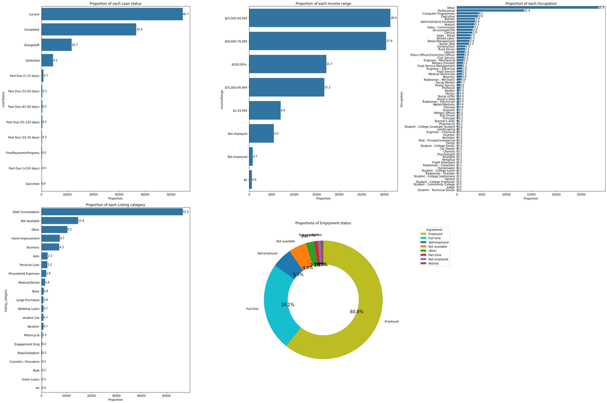

> The categorical vairables dashboard above shows the different categorical variables with relative frequency

### Investigating numerical variables

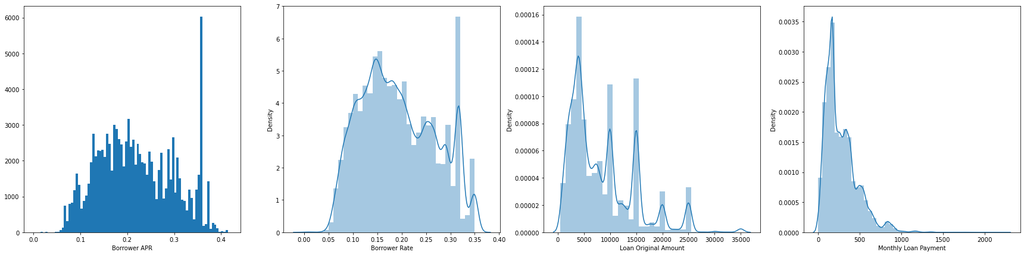

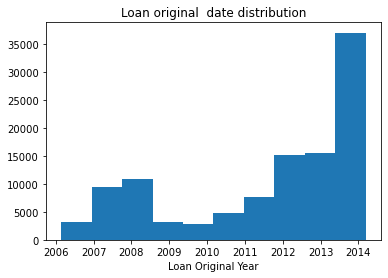

> A general distribution of for each of the numerical variables is presented in the above histrograms

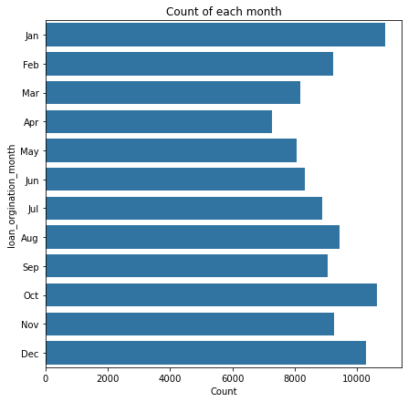

#### **Uni-variate visualisations conclusions:**

**Categorical**

- Almost 56% of loans given where to employees with Income range between ~ 25K - 75K USD
- 51.6% of Listings category is Debt Consolidation
- Employees are more likely to get approved for a loan application

**Numerical**

- Borrower Rate and Borrower APR are similar in distribution
- Right skewed distribution for Monthly loan payment which can be interesting to investigate more if outliers have an effect in this distribution
- There is a trend around april where less loan applications are entered to the system which could be due to yearly vacations or needs more input from domain expert

**Datetime**

- In more recent year we can see an exponential growth in number of loans at year 2014

## Bivariate Exploration

> In the coming figures a mix between boxplots and violin plots are used to show summary statistics between different categorical and numerical variables

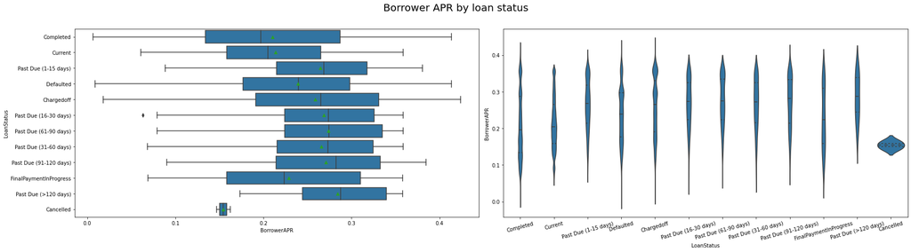

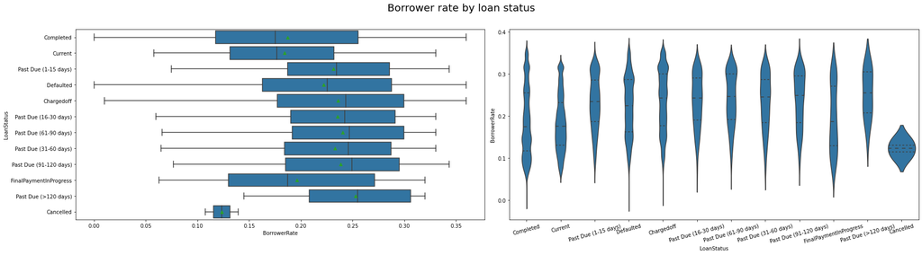

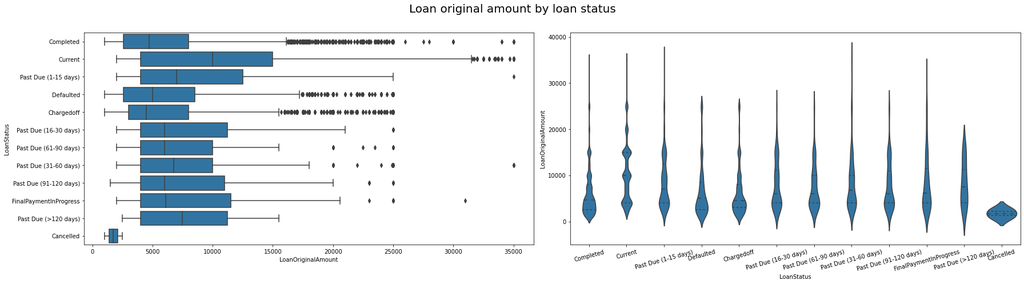

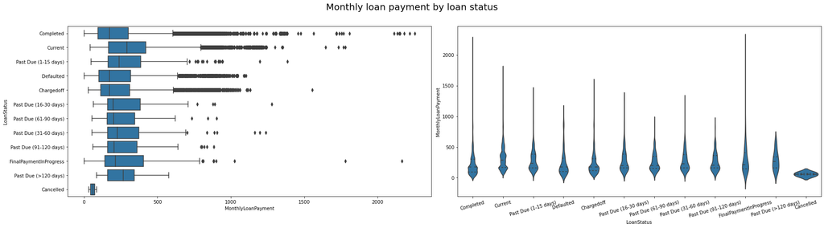

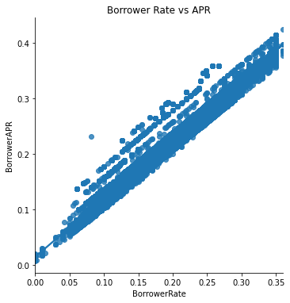

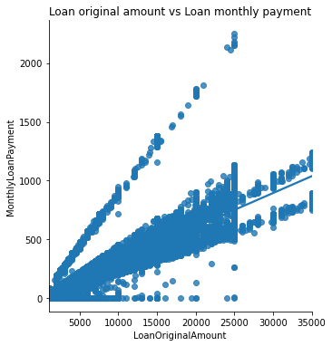

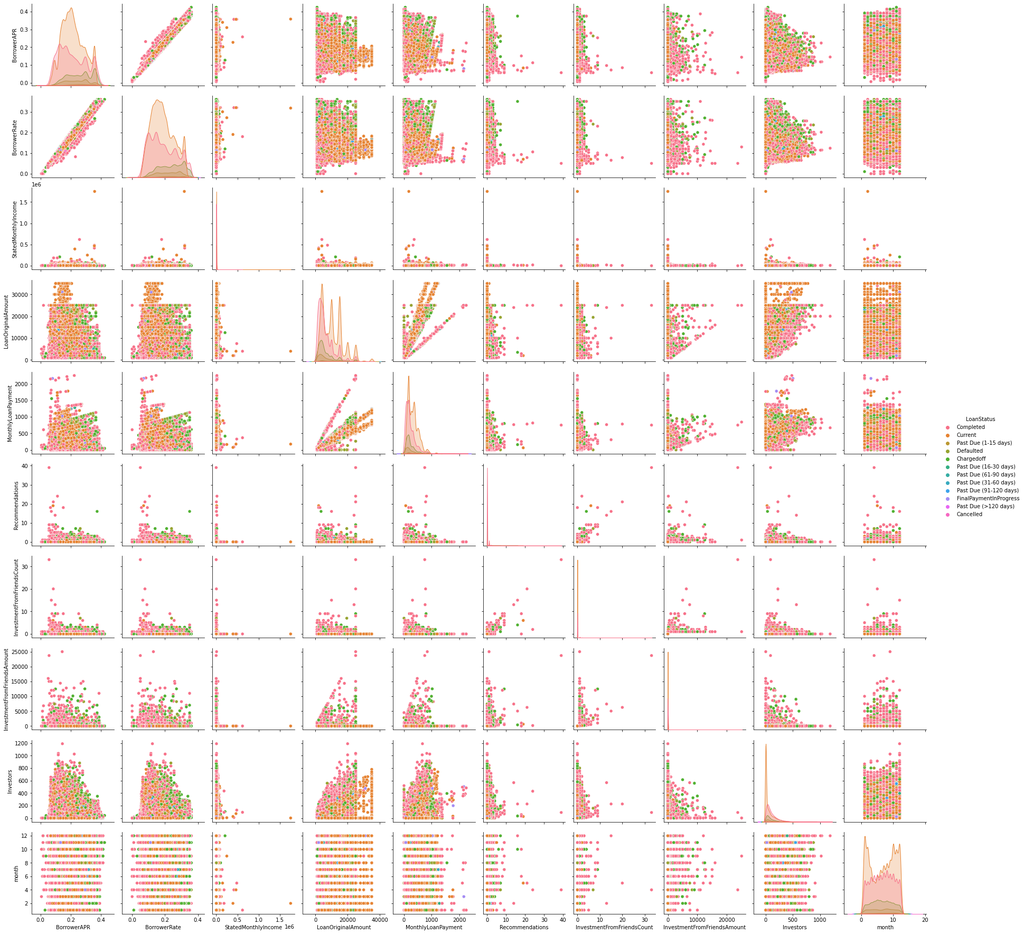

#### **Bi-variate visualisations conclusions:**

From above graphs the below conclusions can be drawn:

## Multivariate Exploration

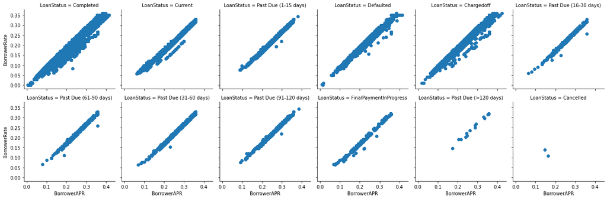

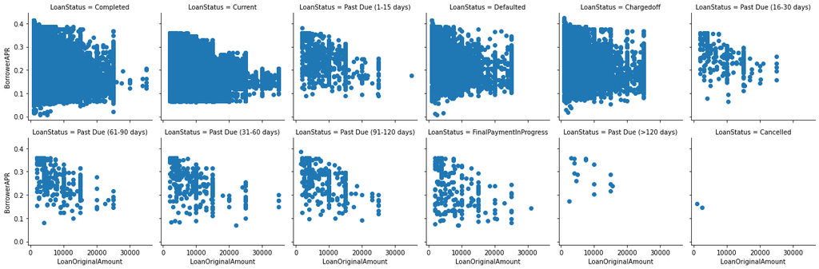

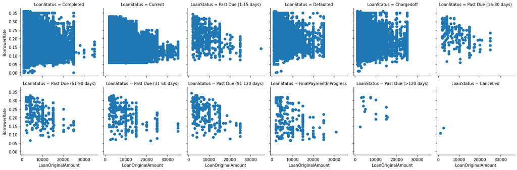

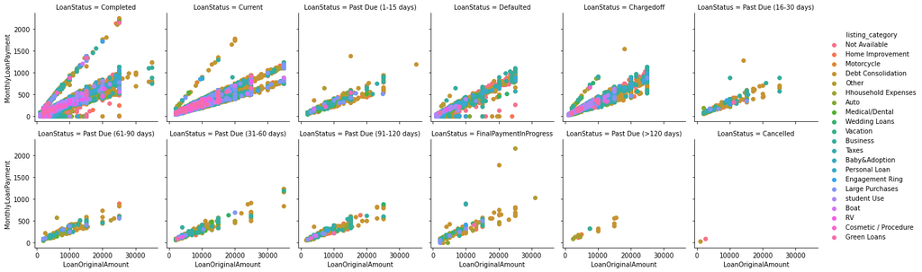

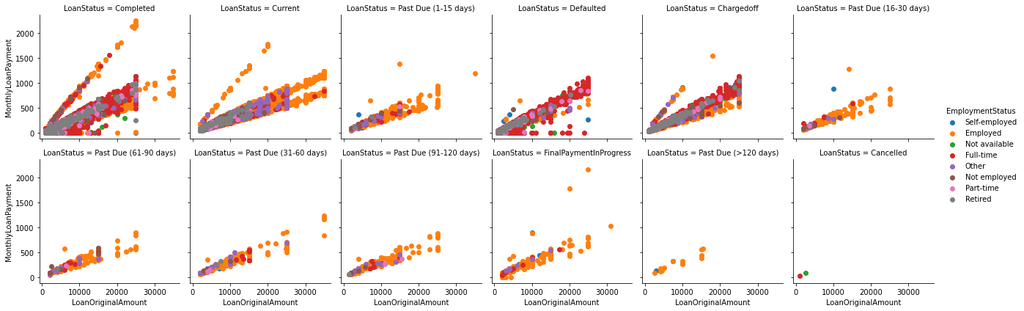

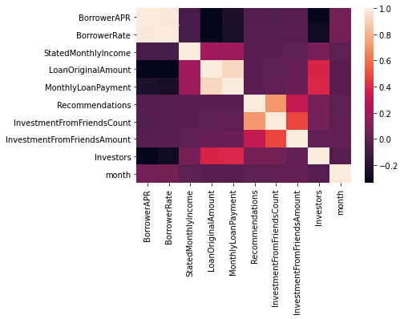